# Supplementary SHAP Rank Stability Analysis for Model 3

2026-06-02

# Aim

This supplementary analysis evaluates the robustness of Model 3 SHAP-derived feature importance rankings across repeated model runs using different random seeds and between the BEAT-AML Waves 1–2 training cohort and the temporally independent Waves 3–4 validation cohort.

Cross-validation was used for hyperparameter optimisation rather than biological feature stability assessment. Because individual cross-validation folds contain only subsets of the training cohort, some fold-wise variation in feature rankings is expected. Therefore, to assess the robustness of SHAP-derived interpretations, we evaluated consistency across repeated random seeds and independent cohorts.

# Input files

This analysis uses the following files generated from the Model 3 SHAP robustness workflow:

- `Model3_SHAP_all_seed_rankings.csv`
- `Model3_SHAP_train_test_overlap.csv`
- `Model3_SHAP_top20_frequency_by_cohort.csv`
- `Model3_SHAP_robust_features.csv`
- `Table_S2.xlsx`, containing the corrected feature-to-biological-layer annotation.

# Load data

```r
all_seed_rankings <- read_csv("Model3_SHAP_all_seed_rankings.csv", show_col_types = FALSE)
train_test_overlap <- read_csv("Model3_SHAP_train_test_overlap.csv", show_col_types = FALSE)
top20_frequency <- read_csv("Model3_SHAP_top20_frequency_by_cohort.csv", show_col_types = FALSE)
robust_features <- read_csv("Model3_SHAP_robust_features.csv", show_col_types = FALSE)
feature_annotation <- read_excel("Table_S2.xlsx") %>%
  mutate(across(everything(), as.character))

N_TOP <- 20
rank_cap <- N_TOP + 1
```

# Helper functions

The model matrix contains one-hot encoded variables, for example `npm1_TRUE.` or `eln_clean_Favorable`. The function below maps these processed model features back to the corresponding original feature name in Table S2 by exact matching or longest-prefix matching.

```r
map_to_original_feature <- function(feature, annotation_features) {
  annotation_features <- annotation_features[order(nchar(annotation_features), decreasing = TRUE)]
  exact_match <- annotation_features[feature == annotation_features]
  if (length(exact_match) > 0) return(exact_match[1])
  prefix_match <- annotation_features[str_starts(feature, paste0(annotation_features, "_"))]
  if (length(prefix_match) > 0) return(prefix_match[1])
  return(NA_character_)
}

clean_feature_label <- function(x) {
  x %>%
    str_replace_all("_TRUE\\.", " mutation") %>%
    str_replace_all("_FALSE\\.", " wild-type") %>%
    str_replace_all("_TRUE", " mutation") %>%
    str_replace_all("_FALSE", " wild-type") %>%
    str_replace_all("_new$", " new") %>%
    str_replace_all("_unknown$", " unknown") %>%
    str_replace_all("eln_clean_", "ELN: ") %>%
    str_replace_all("_", " ")
}

layer_colours <- c(
  "Clinical" = "#4D4D4D",
  "Genomic" = "#1F78B4",
  "Transcriptomic" = "#33A02C",
  "RTE" = "#E31A1C",
  "Unannotated" = "#BDBDBD"
)

feature_map <- all_seed_rankings %>%
  distinct(Feature) %>%
  mutate(
    Original_Feature = map_chr(Feature, map_to_original_feature, annotation_features = feature_annotation$Feature_Name)
  ) %>%
  left_join(feature_annotation, by = c("Original_Feature" = "Feature_Name")) %>%
  mutate(
    Biological_Layer = replace_na(Biological_Layer, "Unannotated"),
    Subcategory = replace_na(Subcategory, "Unannotated"),
    Feature_label = clean_feature_label(Feature)
  )

feature_map %>%
  count(Biological_Layer, name = "N_model_features")
```

```
## # A tibble: 5 × 2
##   Biological_Layer N_model_features
##   <chr>                       <int>
## 1 Clinical                       28
## 2 Genomic                        99
## 3 RTE                             9
## 4 Transcriptomic                 95
## 5 Unannotated                     1
```

# Select robust features for visualization

```r
features_to_show <- robust_features %>%
  arrange(desc(Total_appearances), Mean_rank) %>%
  slice_head(n = 20) %>%
  pull(Feature)

plot_rankings <- all_seed_rankings %>%
  filter(Feature %in% features_to_show) %>%
  left_join(feature_map, by = "Feature") %>%
  mutate(
    Rank_plot = if_else(Rank <= N_TOP, Rank, rank_cap),
    Stability_score = if_else(Rank <= N_TOP, rank_cap - Rank, 0),
    Seed = factor(Seed, levels = sort(unique(Seed))),
    Cohort = factor(Cohort, levels = c("Training", "Test")),
    Column = paste(Cohort, Seed, sep = "\n")
  ) %>%
  group_by(Feature_label) %>%
  mutate(Median_rank = median(Rank_plot, na.rm = TRUE)) %>%
  ungroup() %>%
  mutate(
    Feature_label = fct_reorder(Feature_label, -Median_rank),
    Column = factor(Column, levels = unique(Column[order(Cohort, Seed)])),
    Biological_Layer = factor(Biological_Layer, levels = c("Clinical", "Genomic", "Transcriptomic", "RTE", "Unannotated"))
  )
```

# Panel A: SHAP rank stability across random seeds and cohorts

Darker colour indicates greater stability/higher SHAP importance. A feature ranked first receives the highest stability score, whereas features outside the top 20 receive a score of zero.

```r
p_heatmap <- ggplot(plot_rankings, aes(x = Column, y = Feature_label, fill = Rank_plot)) +
  geom_tile(color = "white", linewidth = 0.35) +
  scale_fill_gradient(
    low = "#08306B",
    high = "#F7FBFF",
    limits = c(1, rank_cap),
    breaks = c(1, 5, 10, 15, 20),
    labels = c("1", "5", "10", "15", "20"),
    name = "SHAP rank\n(lower = more important)"
  ) +
  facet_grid(Biological_Layer ~ ., scales = "free_y", space = "free_y") +
  labs(
    title = "SHAP feature-rank stability across random seeds and cohorts",
    x = NULL,
    y = NULL
  ) +
  theme_classic(base_size = 9) +
  theme(
    plot.title = element_text(face = "bold", size = 10, hjust = 0),
    axis.text.x = element_text(angle = 45, hjust = 1, vjust = 1, size = 7),
    axis.text.y = element_text(size = 7),
    strip.background = element_blank(),
    strip.text.y = element_text(angle = 0, face = "bold", size = 7),
    legend.position = "right",
    panel.spacing.y = unit(0.45, "lines")
  )

p_heatmap
```

[figure not shown]

# Panel B: Concordance of average SHAP ranks between training and validation cohorts

```r
rank_concordance <- all_seed_rankings %>%
  filter(Rank <= N_TOP) %>%
  group_by(Cohort, Feature) %>%
  summarise(
    Mean_rank = mean(Rank),
    Times_in_top20 = n(),
    Mean_importance = mean(Importance),
    .groups = "drop"
  ) %>%
  pivot_wider(
    names_from = Cohort,
    values_from = c(Mean_rank, Times_in_top20, Mean_importance),
    names_sep = "_"
  ) %>%
  filter(!is.na(Mean_rank_Training), !is.na(Mean_rank_Test)) %>%
  left_join(feature_map, by = "Feature") %>%
  mutate(
    Biological_Layer = factor(Biological_Layer, levels = c("Clinical", "Genomic", "Transcriptomic", "RTE", "Unannotated")),
    Label_feature = if_else(
      Mean_rank_Training <= 8 | Mean_rank_Test <= 8 | Feature %in% head(features_to_show, 10),
      Feature_label,
      NA_character_
    )
  )

rank_correlation <- suppressWarnings(
  cor(rank_concordance$Mean_rank_Training, rank_concordance$Mean_rank_Test, method = "spearman")
)
```

```r
p_scatter <- ggplot(rank_concordance, aes(x = Mean_rank_Training, y = Mean_rank_Test)) +
  geom_abline(slope = 1, intercept = 0, linetype = "dashed", linewidth = 0.35, colour = "grey45") +
  geom_point(aes(colour = Biological_Layer), size = 2.6, alpha = 0.9) +
  ggrepel::geom_text_repel(
    aes(label = Label_feature),
    size = 2.4,
    max.overlaps = Inf,
    min.segment.length = 0,
    box.padding = 0.25,
    segment.size = 0.25,
    na.rm = TRUE
  ) +
  scale_colour_manual(values = layer_colours, drop = FALSE) +
  scale_x_reverse(limits = c(20.5, 0.5), breaks = c(20, 15, 10, 5, 1)) +
  scale_y_reverse(limits = c(20.5, 0.5), breaks = c(20, 15, 10, 5, 1)) +
  coord_equal() +
  labs(
    title = "Concordance of SHAP rankings between cohorts",
    subtitle = paste0("Spearman rho = ", round(rank_correlation, 2)),
    x = "Mean SHAP rank in training cohort",
    y = "Mean SHAP rank in validation cohort",
    colour = "Biological layer"
  ) +
  theme_classic(base_size = 9) +
  theme(
    plot.title = element_text(face = "bold", size = 10, hjust = 0),
    plot.subtitle = element_text(size = 8, hjust = 0),
    legend.position = "bottom",
    legend.title = element_text(size = 8),
    legend.text = element_text(size = 7)
  )

p_scatter
```

[figure not shown]

# Panel C: Top-20 overlap between training and validation cohorts across seeds

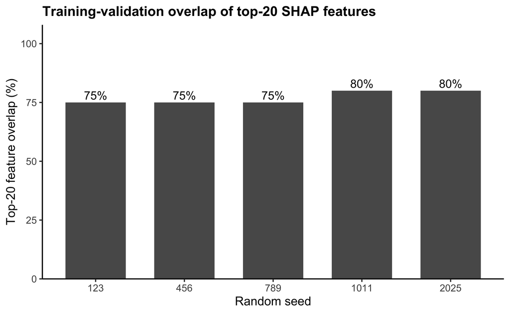

```r
p_overlap <- train_test_overlap %>%
  mutate(Seed = factor(Seed, levels = Seed)) %>%
  ggplot(aes(x = Seed, y = Percent_Overlap)) +
  geom_col(width = 0.68, fill = "grey35") +
  geom_text(aes(label = paste0(Percent_Overlap, "%")), vjust = -0.35, size = 3) +
  scale_y_continuous(limits = c(0, 100), breaks = seq(0, 100, 25), expand = expansion(mult = c(0, 0.08))) +
  labs(
    title = "Training-validation overlap of top-20 SHAP features",
    x = "Random seed",
    y = "Top-20 feature overlap (%)"
  ) +
  theme_classic(base_size = 9) +
  theme(plot.title = element_text(face = "bold", size = 10, hjust = 0))

p_overlap
```

# Combined supplementary figure

```r
combined_figure <- p_heatmap | (p_scatter / p_overlap)
combined_figure + plot_annotation(
  title = "Supplementary Figure X. Robustness of Model 3 SHAP-derived feature rankings",
  theme = theme(plot.title = element_text(face = "bold", size = 12))
)
```

[figure not shown]

```r
ggsave(
  "Supplementary_Figure_Model3_SHAP_rank_stability_TableS2.pdf",
  plot = combined_figure,
  width = 12,
  height = 8.5,
  units = "in",
  device = cairo_pdf
)

ggsave(
  "Supplementary_Figure_Model3_SHAP_rank_stability_TableS2.png",
  plot = combined_figure,
  width = 12,
  height = 8.5,
  units = "in",
  dpi = 600
)
```